# Results

A simulation that reports only finite-sample bias cannot distinguish an estimator that is *biased because the sample is small* from one that is *biased because it is the wrong model*. The two carry opposite practical implications—the first is remedied by collecting more data, the second is not— yet at any single sample size they are indistinguishable. The central analytic device of this study is therefore a decomposition of an estimator’s total error into components with distinct asymptotic fates, made possible by pairing the Monte Carlo estimates with the estimator’s analytic probability limit (plim).

## The decomposition

All estimators are benchmarked against the effects-coding–aligned population target $\boldsymbol{\Phi}_{\mathrm{ec}}=\mathbf{M}\boldsymbol{\Phi}_{\mathrm{gen}}\mathbf{M}'$, the *common* estimand on which the sum-score 1-LGCM and the EC-fitted 2-LGCM are made commensurable (see Method). With a common target in place, the relative bias of a parameter at sample size $N$ decomposes additively:

$$\underbrace{\frac{E[\hat\theta_N]-\theta_{\mathrm{ec}}}{\theta_{\mathrm{ec}}}}_{\text{total
relative bias}}
=
\underbrace{\frac{E[\hat\theta_N]-\operatorname{plim}\hat\theta}{\theta_{\mathrm{ec}}}}_{\text{finite-sample
component}}
+
\underbrace{\frac{\operatorname{plim}\hat\theta-\theta_{\mathrm{ec}}}{\theta_{\mathrm{ec}}}}_{\text{asymptotic
component}} .$$

The **asymptotic component** is the discrepancy that survives as $N\to\infty$: it is zero if and only if the estimator is consistent for the target, and nonzero precisely when the fitted model is misspecified in a way it cannot represent. The **finite-sample component** is the remaining gap between the expected estimate at $N$ and the plim; for a consistent estimator it is the entire bias and it vanishes with $N$. We obtain $\operatorname{plim}\hat\theta$ analytically—by fitting each model to the *exact* population moments of the generating mechanism—so the decomposition is exact and free of Monte Carlo noise. Because the three quantities share the denominator $\theta_{\mathrm{ec}}$, they add exactly.

Once the target is the aligned $\boldsymbol{\Phi}_{\mathrm{ec}}$, a *scale* discrepancy between composite and latent metrics cannot enter the bias at all; it has been absorbed by the alignment. What remains for the decomposition to adjudicate are three substantively different sources: a vanishing **small-sample** effect (nonzero finite-sample component, zero asymptotic component), a genuine **inconsistency** (nonzero asymptotic component), and— as shown below—a **selection** artifact that arises when the admissibility screening applied to Monte Carlo replications removes part of the sampling distribution.

## Asymptotic component: consistency holds except under unrepresentable misspecification

The asymptotic component is zero, to numerical precision, in every correctly specified cell—both models, both reliabilities, all $J$, $T\in\{3,5\}$, and $\rho=.15$ once lag-1 correlated uniqueness (CU) is modeled where identified (maximum $|$asymptotic relative bias$|<1\times10^{-6}$; Table 1). The longitudinal EC alignment is thereby validated, and the sum-score 1-LGCM is shown to be consistent for the *same* estimand whenever correctly specified.

A nonzero asymptotic component appears only in the $\{T=3,\rho=.15\}$ cells, where the data carry a lag-1 CU that cannot be modeled: adding CU to the sum-score 1-LGCM at $T=3$ would require 10 parameters for 9 nonredundant moments ($df=-1$), so CU is omitted from both fitted models for comparability. There the asymptotic bias is large—the slope variance is inflated by 53% (good reliability) to 234% (poor), and the intercept–slope correlation is attenuated or sign-reversed (Table 1). Crucially the EC and sum-score models share this asymptotic bias almost exactly; when CU is present but unrepresentable, the second-order structure confers no asymptotic protection.

**Table 1. Asymptotic component (plim $-$ target, relative).**

| Condition | Model | Reliability | $\phi_{22}$ | $\rho_{IS}$ |
| --- | --- | --- | --- | --- |
| All correctly specified cells | both | both | $<10^{-6}$ | $<10^{-6}$ |
| $T=3,\rho=.15$ (CU omitted) | EC | $R^2=.45$ | $+.53$ | $-.70$ |
| $T=3,\rho=.15$ | EC | $R^2=.16$ | $+2.29$ | $-1.60$ |
| $T=3,\rho=.15$ | Sum | $R^2=.45$ | $+.54$ | $-.71$ |
| $T=3,\rho=.15$ | Sum | $R^2=.16$ | $+2.34$ | $-1.61$ |

## The decomposition in practice: same symptom, different disease

Table 2 applies the decomposition to the slope variance $\phi_{22}$ in three conditions whose *total* bias is similar in magnitude but whose *composition*— and therefore whose diagnosis—is entirely different. Figure 1 shows the same information as convergence toward the $N=\infty$ plim.

**Table 2. Decomposition of total relative bias in $\phi_{22}$ (total $=$ finite-sample $+$ asymptotic).**

| Case | Model, condition | $N$ | total | finite-sample | asymptotic |
| --- | --- | --- | --- | --- | --- |
| **A** | EC, $T=3,\rho=0$ ($R^2=.45$) | 200 | $.47$ | $.47$ | $.00$ |
|  |  | 500 | $.24$ | $.24$ | $.00$ |
|  |  | 800 | $.16$ | $.16$ | $.00$ |
| **B** | Sum, $T=3,\rho=.15$ ($R^2=.45$) | 200 | $.78$ | $.24$ | $.54$ |
|  |  | 500 | $.59$ | $.04$ | $.54$ |
|  |  | 800 | $.55$ | $.01$ | $.54$ |
| **C** | EC, $T=3,\rho=.15$ ($R^2=.45$) | 200 | $.45$ | $-.08$ | $.53$ |
|  |  | 500 | $.22$ | $-.32$ | $.53$ |
|  |  | 800 | $.13$ | $-.40$ | $.53$ |

**Case A — small sample (a benign, vanishing artifact).** Under correct specification at $T=3$, the EC model’s slope-variance bias is large at small samples ($+47\%$ at $N=200$) but is *entirely* finite-sample: the asymptotic component is zero, and the bias falls monotonically toward it ($+16\%$ at $N=800$). The slope variance is simply hard to estimate from a single increment; the estimator is consistent and the problem is remedied by more data (or more occasions). Reporting the $N=200$ figure alone would wrongly indict a correct model.

**Case C — selection (a screening artifact, not consistency).** The EC model in the *identical* misspecified condition appears, on admissible replications, to have a *smaller* and *shrinking* total bias ($+45\%\to+13\%$). Taken at face value this would suggest the EC model is the better choice at $T=3$. The decomposition shows otherwise: its asymptotic component ($+.53$) equals the sum-score model’s, but its finite-sample component is large and *negative*, and grows more negative with $N$ ($-.08\to-.40$)—the admissible-sample mean is moving *away* from the plim. The cause is that the EC model’s unconstrained probability limit in this cell is itself **inadmissible**: the population solution places a negative disturbance on the final wave ($s_3=-.092$), a Heywood case at $N=\infty$. The admissibility screen applied to each replication therefore removes the upper tail of the slope-variance distribution, so the admissible-only mean targets a constrained boundary rather than the plim. The apparently milder bias of the EC model at $T=3$ is thus a selection artifact of conditioning on admissibility, not evidence of better recovery.

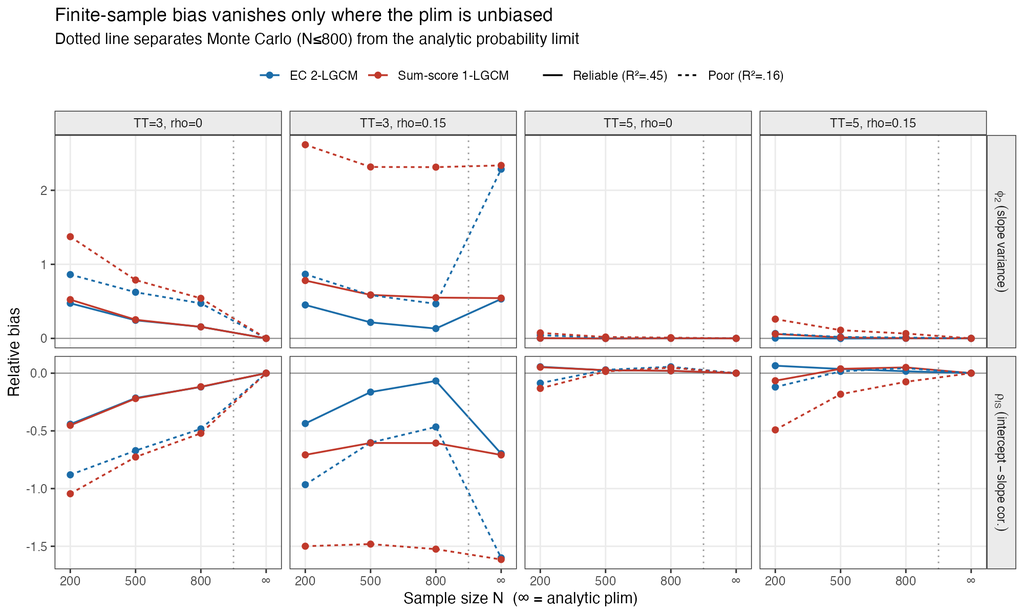

Figure 1. Total relative bias against sample size, with the analytic plim as the $N=\infty$ anchor.

That Case A and Case B are genuinely different is confirmed at $T=5$, where the finite-sample component is the *only* component for both models. There the sum-score slope-variance bias under $\rho=.15$ is finite-sample throughout (poor reliability: $+.26$ at $N=200$, $+.07$ at $N=800$, asymptotic component $0$) and the EC model is essentially unbiased at every $N$. With enough occasions to identify and model CU, both estimators are consistent and behave accordingly; the decomposition attributes their finite-$N$ differences to sampling, not to misspecification.

## Diagnostic signatures

**Table 3. Observable signatures of each component (selected rows).**

| Case | Model, condition | $N$ | total bias | $\phi_{22}$ cov | $\rho_{IS}$ cov | % admissible |
| --- | --- | --- | --- | --- | --- | --- |
| A (small sample) | EC, $T=3,\rho=0$, poor | 200 | $.86$ | $.99$ | $.79$ | $.36$ |
| B (inconsistency) | Sum, $T=3,\rho=.15$, poor | 200 | $2.62$ | $.76$ | $.41$ | $.92$ |
| B (inconsistency) | Sum, $T=3,\rho=.15$, poor | 800 | $2.31$ | $.38$ | $.16$ | $1.00$ |
| recovered | EC, $T=5,\rho=.15$, good | 800 | $-.00$ | $.95$ | $.95$ | $1.00$ |

## Summary of findings

The decomposition resolves the apparent failures of these growth estimators into their true causes. (1) After alignment to the common estimand $\boldsymbol{\Phi}_{\mathrm{ec}}$, scale discrepancy is removed by construction. (2) Under correct specification both the EC-fitted 2-LGCM and the sum-score 1-LGCM are consistent; with $T=5$ occasions this is realized in practice, the EC model being essentially unbiased with nominal coverage. (3) At $T=3$, growth- variance bias under correct specification is *entirely finite-sample*—large but vanishing—and must not be mistaken for a defect of the model. (4) When correlated uniqueness is present but unrepresentable ($T=3$), both estimators incur the *same* asymptotic bias, which no sample size removes; the second-order EC model offers no asymptotic protection. (5) On admissible replications the EC model nonetheless *appears* less biased at $T=3$, but this is a selection artifact: its unconstrained plim is an inadmissible Heywood solution, so conditioning on admissibility distorts the comparison. Distinguishing these four sources—scale, small sample, inconsistency, and selection—requires the plim; finite-sample bias alone conflates them.